# Practical Machine Learning Course Project

Kapil Marwah

August 11, 2019

## Load important libraries and read the training data

```r
library(caret)
```

```r
trainingRead <- read.csv("https://d396qusza40orc.cloudfront.net/predmachlearn/pml-training.csv", stringsAsFactors = FALSE)
trainingRead$classe <- as.factor(trainingRead$classe)
head(trainingRead)
```

[output not shown]

[output cut: 265 more lines]

## Data Cleaning

Remove the columns having only NA values

```r
training_withoutna <- trainingRead[,(colSums(is.na(trainingRead)) == 0)]
dim(training_withoutna)
```

```
## [1] 19622    93
```

Remove near Zero variance columns and first five columns which are not relevant for prediction

```r
training_cleaned <- training_withoutna[,-nearZeroVar(training_withoutna)]
training_cleaned <- training_cleaned[,-c(1:5)]
dim(training_cleaned)
```

```
## [1] 19622    54
```

```r
head(training_cleaned)
```

```
##   num_window roll_belt pitch_belt yaw_belt total_accel_belt gyros_belt_x
## 1         11      1.41       8.07    -94.4                3         0.00
## 2         11      1.41       8.07    -94.4                3         0.02
## 3         11      1.42       8.07    -94.4                3         0.00
## 4         12      1.48       8.05    -94.4                3         0.02
## 5         12      1.48       8.07    -94.4                3         0.02
## 6         12      1.45       8.06    -94.4                3         0.02
##   gyros_belt_y gyros_belt_z accel_belt_x accel_belt_y accel_belt_z
## 1         0.00        -0.02          -21            4           22
## 2         0.00        -0.02          -22            4           22
## 3         0.00        -0.02          -20            5           23
## 4         0.00        -0.03          -22            3           21
## 5         0.02        -0.02          -21            2           24
## 6         0.00        -0.02          -21            4           21
##   magnet_belt_x magnet_belt_y magnet_belt_z roll_arm pitch_arm yaw_arm
```

[output cut: 69 more lines]

## Training and Dummy test data partition

Create training and dummy testing data set out of given training data set

Training dimensions

```
## [1] 14718    54
```

Dummy testing data dimensions

```
## [1] 4904   54
```

Cleaned data’s dimensions

```
## [1] 19622    54
```

## Data Train

We would be using random forest model to train our training dataset as it has high accuracy. If requisite accuracy is not achieved then would move to next suitable method like KNN, gbm etc or a combination.

Do parallel processing as Random forest method would be resource heavy

Train the data using random forest model and plot

```
##
## Call:
##  randomForest(x = x, y = y, mtry = param$mtry, tryControl = ..1)
##                Type of random forest: classification
##                      Number of trees: 500
## No. of variables tried at each split: 27
##
##         OOB estimate of  error rate: 0.18%
## Confusion matrix:
##      A    B    C    D    E  class.error
## A 4183    1    0    0    1 0.0004778973
## B    6 2839    3    0    0 0.0031601124
## C    0    5 2562    0    0 0.0019477990
## D    0    0    5 2407    0 0.0020729685
## E    0    1    0    4 2701 0.0018477458
```

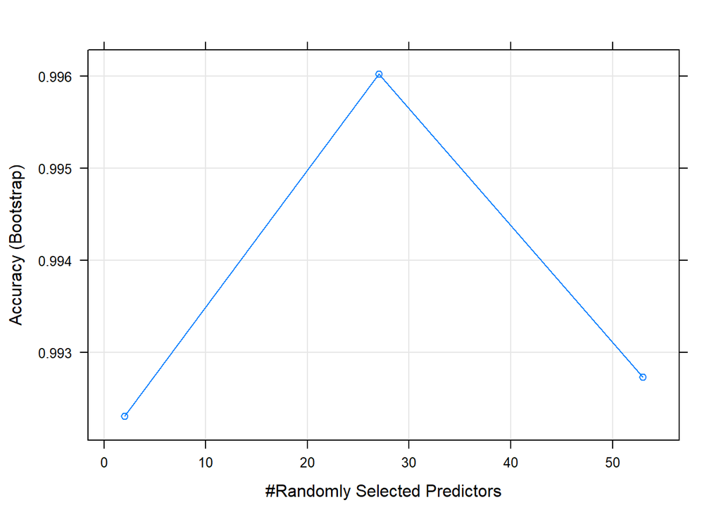

Predict on dummy test data

```
## Confusion Matrix and Statistics
##
##           Reference
## Prediction    A    B    C    D    E
##          A 1395    0    0    0    0
##          B    2  947    0    0    0
##          C    0    1  854    0    0
##          D    0    0    4  800    0
##          E    0    0    0    3  898
##
## Overall Statistics
##
##                Accuracy : 0.998
##                  95% CI : (0.9963, 0.999)
##     No Information Rate : 0.2849
##     P-Value [Acc > NIR] : < 2.2e-16
##
##                   Kappa : 0.9974
##
##  Mcnemar's Test P-Value : NA
##
## Statistics by Class:
##
##                      Class: A Class: B Class: C Class: D Class: E
## Sensitivity            0.9986   0.9989   0.9953   0.9963   1.0000
## Specificity            1.0000   0.9995   0.9998   0.9990   0.9993
## Pos Pred Value         1.0000   0.9979   0.9988   0.9950   0.9967
## Neg Pred Value         0.9994   0.9997   0.9990   0.9993   1.0000
## Prevalence             0.2849   0.1933   0.1750   0.1637   0.1831
## Detection Rate         0.2845   0.1931   0.1741   0.1631   0.1831
## Detection Prevalence   0.2845   0.1935   0.1743   0.1639   0.1837
## Balanced Accuracy      0.9993   0.9992   0.9975   0.9976   0.9996
```

## Prediction on real test data

Read the real test data

```r
realtesting <- read.csv("https://d396qusza40orc.cloudfront.net/predmachlearn/pml-testing.csv", stringsAsFactors = FALSE)
dim(realtesting)
```

```
## [1]  20 160
```

Pick columns as per previously cleaned training data and predict accordingly

```
## [1] 20 53
```

```
##  [1] B A B A A E D B A A B C B A E E A B B B
## Levels: A B C D E
```

This prediction would help in answering the 20 cases quiz.